# Bjorneraas filtering algorithm

David

3/22/2021

The following is the method presented in Bjorneraas et al. 2010 Screening Global Positioning System Location Data for Errors Using Animal Movement Characteristics. The Journal of Wildlife Management 74:1361–1366.

```r
library(adehabitatLT)
```

There are two main functions:

1. GPS.screening applies the algorithm in two steps  
   step 1: remove all points that are far off  
   step 2: detect spikes (high outgoing and incoming speed and a sharp return)
2. GPS.screening.wrp prepares data for the screening algorithm

GPS.screening

Argument list:  
- medcrit: $\Delta$, the cutoff value for the median, which is used in the first step from the first round  
- meancrit: $\mu$, the cutoff value for the mean, which is used in the second step from the first round  
- spikesp: $\alpha$, the criterion for the speed of the outgoing and incoming move, which is used in the second round  
- spikecos: $\theta$, the criterion for the cosine of the angle associated with the outgoing and incoming move, which is used in the second round

Here are the values used for moose in their paper:  
$\Delta$ 100,000 meters  
$\mu$ 10,000 meters  
$\alpha$ = 1500 meters/hour  
$\theta$ = -0.97

```r
GPS.screening <- function(x, medcrit, meancrit, spikesp, spikecos){
    ###round one:
    #############
    ###remove points far off:
    RoundOne <- function(x, df, win, MM){
        if (x<=win){
            dfT <- df[c(1:2*win),]
        }
        if (x>(nrow(df)-win)){
            dfT <- df[c((nrow(df)-2*win):(nrow(df))),]
        }
        if (x>win & x<=(nrow(df)-win)){
            dfT <- df[c((x-win):(x+win)),]
        }
        if (MM=="mean"){
            temp <- sqrt((df$x[x]-mean(dfT$x, na.rm=T))^2+(df$y[x]-mean(dfT$y, na.rm=T))^2)
                                        #calculate the distance between the mean and the focal point
        }
        if (MM=="median"){
            temp <- sqrt((df$x[x]-median(dfT$x, na.rm=T))^2+(df$y[x]-median(dfT$y, na.rm=T))^2)
                                        #calculate the distance between the median and the focal point
        }
        return(temp)
    }

    ##get the points that are really far off, by using the median
    x$R1dmed <- unlist(lapply(c(1:nrow(x)), RoundOne, df=x, win=10, MM="median"))

    ##get the points that are rather far off, by using the mean
    x$R1dmean <- meancrit+1
    x$R1dmean[x$R1dmed<medcrit] <- unlist(lapply(c(1:nrow(x[x$R1dmed<medcrit,])),  RoundOne, df=x[x$R1dmed<medcrit,], win=10, MM="mean"))
    x$R1error <- ifelse(x$R1dmean>meancrit, TRUE, FALSE)

    ###round two:
    #############
    ##find spikes
    xT <- x[x$R1error==FALSE,]
    xT <- as.ltraj(xT[,c("x","y")], date=xT$date, id=xT$id)[[1]]

    x$R2error <- NA
    x$R2error[x$R1error==FALSE] <- ((xT$dist/xT$dt*3600)>spikesp & c(NA, (xT$dist/xT$dt*3600)[-nrow(xT)])>spikesp & cos(xT$rel.angle)<(spikecos))
    return(x)
}
```

GPS.screening.wrp

Format of those vectors has to be:  
- id: numeric, character or factor  
- x: numeric  
- y: numeric  
- date: POSIXct

```r
GPS.screening.wrp <- function(id, x, y, da, medcrit, meancrit, spikesp, spikecos){
    mydata <- ld(as.ltraj(id = id, xy = data.frame(x=x,y=y), date = da))
    mydata <- split(mydata, mydata$id)
    mydata <- lapply(mydata, GPS.screening, medcrit=medcrit, meancrit=meancrit, spikesp=spikesp, spikecos=spikecos)
    mydata <- do.call("rbind", mydata)
    return(data.frame(id=mydata$id, x=mydata$x, y=mydata$y, date=mydata$date, R1dmed=mydata$R1dmed, R1dmean=mydata$R1dmean, R1error=mydata$R1error, R2error=mydata$R2error))
}
```

##An example

### Create a trajectory

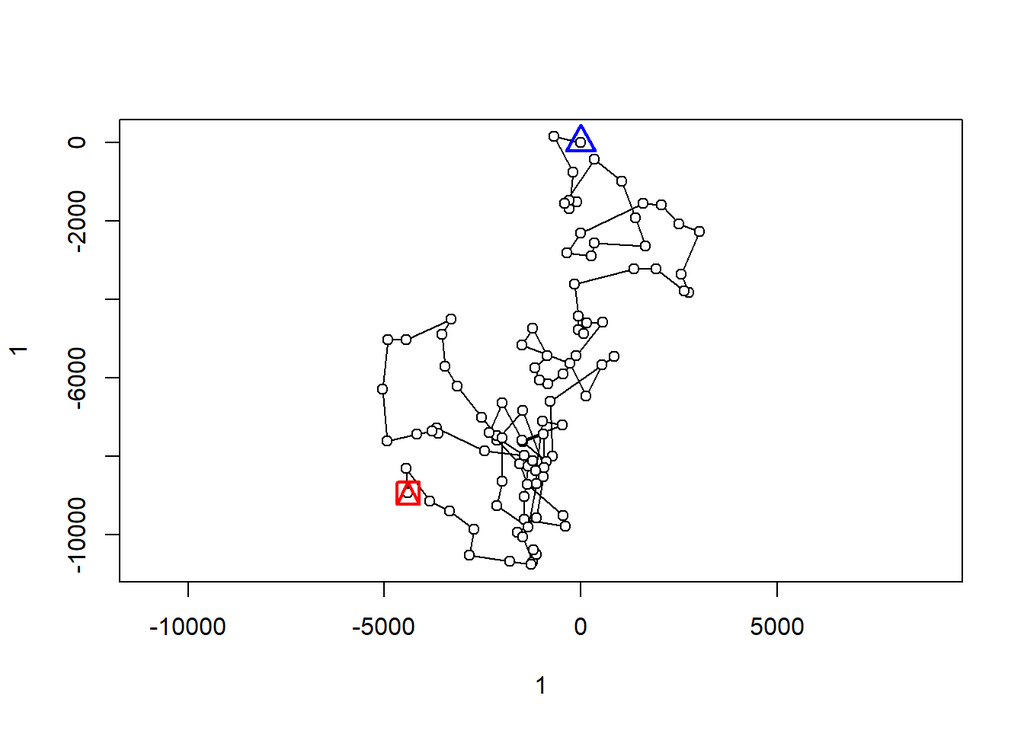

```r
set.seed(0)
demo <- simm.crw(date=as.POSIXct(c(1:100)*3600, origin="1970-01-01"), h=10, r=0.2, id="bob")
plot(demo)
```

```r
demo <- ld(demo)
demo <- demo[, c("id", "x", "y", "date")]
```

### Introduce some errors

2 consecutive points real far off

```r
demo$x[5:6] <- demo$x[5:6]+500000
demo$y[5:6] <- demo$y[5:6]+500000
```

### A spike

```r
demo$x[49] <- demo$x[50]
demo$y[49] <- demo$y[50]
demo$x[51] <- demo$x[50]
demo$y[51] <- demo$y[50]
demo$x[50] <- demo$x[50]+1500
demo$y[50] <- demo$y[50]+1500
```

Plot

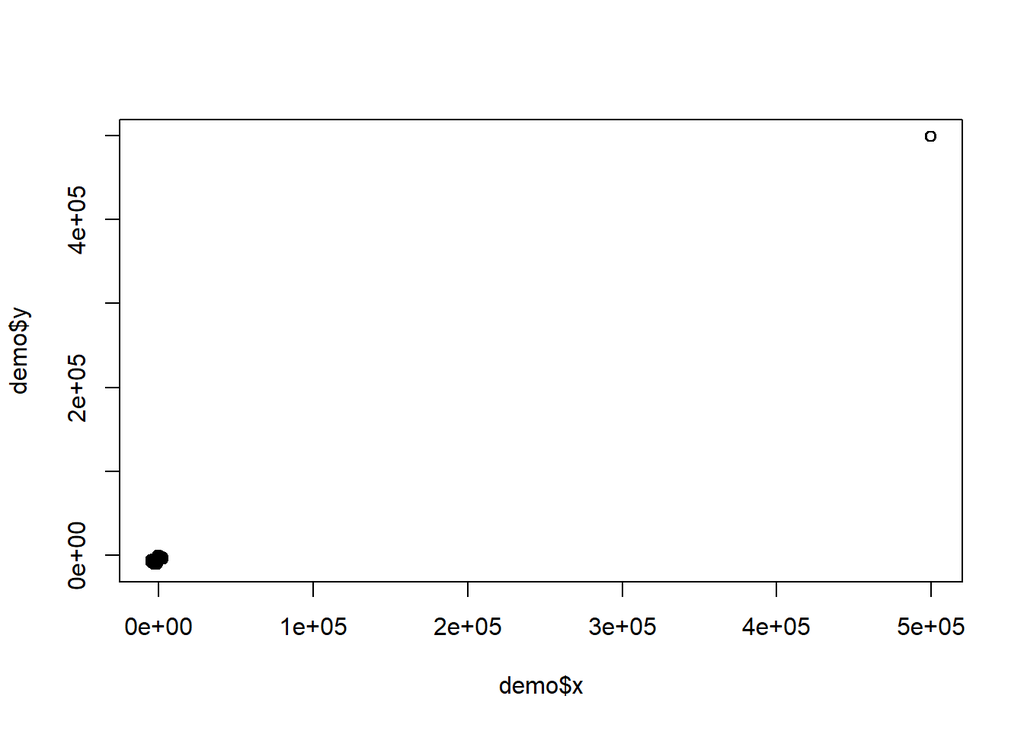

```r
plot(demo$x, demo$y)
```

### Apply screening script

```r
demo <- GPS.screening.wrp(demo$id, demo$x, demo$y, demo$date, medcrit=100000, meancrit=10000, spikesp=1500, spikecos=(-0.97))
demo[c(1:9, 45:54),]
```

```
##     id           x           y                date      R1dmed     R1dmean
## 1  bob      0.0000      0.0000 1969-12-31 19:00:00   3299.3844  3513.97021
## 2  bob   -682.3358    143.0267 1969-12-31 20:00:00   3851.0130  3971.79910
## 3  bob   -202.3560   -760.1536 1969-12-31 21:00:00   2880.1692  2954.52279
## 4  bob   -292.4293  -1687.5043 1969-12-31 22:00:00   2464.4031  2325.38116
## 5  bob 499911.2108 498490.4546 1969-12-31 23:00:00 706444.9398 10001.00000
## 6  bob 499699.7862 498520.3563 1970-01-01 00:00:00 706317.1514 10001.00000
## 7  bob   -399.3659  -1547.9762 1970-01-01 01:00:00   2618.3561  2497.30101
## 8  bob    350.0857   -425.3575 1970-01-01 02:00:00   2749.1423  2983.53827
## 9  bob   1050.8974   -996.5066 1970-01-01 03:00:00   1887.0825  2230.13609
## 45 bob   -866.9182  -8140.2152 1970-01-02 15:00:00    704.6474  1029.74309
## 46 bob  -1477.8991  -7633.3022 1970-01-02 16:00:00    612.0205   721.42460
## 47 bob   -946.2105  -7435.5678 1970-01-02 17:00:00    162.5851    74.24356
## 48 bob   -933.3604  -8289.5948 1970-01-02 18:00:00    656.2926   734.68490
## 49 bob  -2134.3296  -7597.6443 1970-01-02 19:00:00   1228.7528  1202.38864
```

[output cut: 25 more lines]